# Growth rate analysis

Patrick Thomas

Nov 7 2021

# 1 Setup, data import and checking

> load packages and set theme

> run the following to install growthTools and its required packages, if necessary

```r
# install.packages("remotes")
# remotes::install_github("ctkremer/mleTools")
# remotes::install_github("ctkremer/growthTools")
library(growthTools)
```

> create list of files to combine

```r
#create list of growth data files
growth_files <- list.files("C:/Users/pktho/OneDrive/Growth rates paper/growth_rate_project", # change this based on location of files
                        pattern = "growthdata.csv",  # Limit to just files ending in growthdata.csv
                        recursive = TRUE,  # Search within subfolders
                        full.names = TRUE) # Return full paths

growth_files
```

```
## [1] "C:/Users/pktho/OneDrive/Growth rates paper/growth_rate_project/AL_MG_growthdata.csv"
## [2] "C:/Users/pktho/OneDrive/Growth rates paper/growth_rate_project/irene_growthdata.csv"
## [3] "C:/Users/pktho/OneDrive/Growth rates paper/growth_rate_project/patrick_growthdata.csv"
## [4] "C:/Users/pktho/OneDrive/Growth rates paper/growth_rate_project/Vanessa_expA_growthdata.csv"
```

```r
# create list of metadata files
metadata_files <- list.files("C:/Users/pktho/OneDrive/Growth rates paper/growth_rate_project", # change this based on location of files
                        pattern = "metadata.csv",  # Limit to just files ending in growthdata.csv
                        recursive = TRUE,  # Search within subfolders
                        full.names = TRUE) # Return full paths

metadata_files
```

```
## [1] "C:/Users/pktho/OneDrive/Growth rates paper/growth_rate_project/Vanessa_expA_metadata.csv"
```

> combine data files based on above list

```r
df <- lapply(growth_files, function(i){
  x=read_csv(i, na = "NA", col_types = cols(colonial = col_character(),
                                            time_acclimation = col_character(),
                                            RFU_excitation_emission = col_character()))
  x$filename = i
  x
})

#df[[1]] # to look at a certain data file for example

df=do.call("bind_rows", df) # binds all data frames read in above, but requires same column names or it will create duplicat columns!

#combine researcher ID with unique ID to make sure it's unique across all datasets
df <- df %>% mutate(unique_ID = paste(researcher_ID, unique_ID, sep = '_'))
```

> combine metadata files based on above metadata file list

```r
metadata <- lapply(metadata_files, function(i){
  x=read_csv(i, na = "NA", col_types = cols(colonial = col_character(),
                                            time_acclimation = col_character(),
                                            RFU_excitation_emission = col_character()))
  x$filename = i
  x
})

metadata=do.call("bind_rows", metadata)
metadata <- metadata %>% mutate(unique_ID = paste(researcher_ID, unique_ID, sep = '_'))
```

> stuff I have to do for now since metadata is in different places for different people

```r
df <- df %>% select(researcher_ID:cell_density)
df_Vanessa <- df %>% filter(researcher_ID=="Vanessa")
df_Vanessa <- left_join(df_Vanessa, metadata)
df <- df %>% filter(researcher_ID!="Vanessa")
df <- bind_rows(df, df_Vanessa)
```

> calculate sampling intervals, total number samples [probably add more things here later e.g., hour to day conversions, other stuff like that if necessary]

```r
df <- df %>%
  #calculate number of observations and time between all observations
  group_by(unique_ID) %>%
  mutate(time_points = length(time_days),
            interval = time_days - dplyr::lag(time_days, n =1))

df <- left_join(df, metadata)
```

> check out the combined data in several ways to make sure it all makes sense and was imported correctly

```r
dim(df)
```

```
## [1] 96589    31
```

```r
names(df)
```

```
##  [1] "researcher_ID"                "unique_ID"
##  [3] "time_days"                    "time_hours"
##  [5] "RFU_platereader"              "RFU_excitation_emission"
##  [7] "RFU_handheld"                 "OD"
##  [9] "biomass_C"                    "chla_extracted"
## [11] "OD_wavelength"                "cell_density"
## [13] "cell_density_technique"       "system"
## [15] "taxa_broad"                   "natural_artificial_community"
## [17] "species_richness"             "species_name"
## [19] "time_acclimation"             "time_frequency_sampling"
## [21] "L_D_cycle"                    "colonial"
## [23] "zooplankton_present"          "dissolved N"
## [25] "dissolved P"                  "culture medium"
## [27] "light intensity"              "temperature"
## [29] "filename"                     "time_points"
## [31] "interval"
```

```r
str(df)
```

```
## grouped_df [96,589 x 31] (S3: grouped_df/tbl_df/tbl/data.frame)
##  $ researcher_ID               : chr [1:96589] "AH" "AH" "AH" "AH" ...
##  $ unique_ID                   : chr [1:96589] "AH_2020_196" "AH_2020_196" "AH_2020_196" "AH_2020_196" ...
##  $ time_days                   : num [1:96589] 0 2 4 6 8 10 12 14 16 18 ...
##  $ time_hours                  : num [1:96589] NA NA NA NA NA NA NA NA NA NA ...
##  $ RFU_platereader             : num [1:96589] 11 9 11 22 45 74 85 63 80 64 ...
##  $ RFU_excitation_emission     : chr [1:96589] "395.68" "395.68" "395.68" "395.68" ...
##  $ RFU_handheld                : logi [1:96589] NA NA NA NA NA NA ...
##  $ OD                          : num [1:96589] 0.043 0.043 0.048 0.054 0.051 0.056 0.056 0.055 0.062 0.055 ...
##  $ biomass_C                   : logi [1:96589] NA NA NA NA NA NA ...
##  $ chla_extracted              : logi [1:96589] NA NA NA NA NA NA ...
##  $ OD_wavelength               : num [1:96589] 440 440 440 440 440 440 440 440 440 440 ...
##  $ cell_density                : logi [1:96589] NA NA NA NA NA NA ...
##  $ cell_density_technique      : logi [1:96589] NA NA NA NA NA NA ...
##  $ system                      : chr [1:96589] NA NA NA NA ...
##  $ taxa_broad                  : chr [1:96589] NA NA NA NA ...
##  $ natural_artificial_community: chr [1:96589] NA NA NA NA ...
##  $ species_richness            : num [1:96589] NA NA NA NA NA NA NA NA NA NA ...
##  $ species_name                : chr [1:96589] NA NA NA NA ...
##  $ time_acclimation            : chr [1:96589] NA NA NA NA ...
##  $ time_frequency_sampling     : chr [1:96589] NA NA NA NA ...
##  $ L_D_cycle                   : num [1:96589] NA NA NA NA NA NA NA NA NA NA ...
##  $ colonial                    : chr [1:96589] NA NA NA NA ...
##  $ zooplankton_present         : chr [1:96589] NA NA NA NA ...
##  $ dissolved N                 : num [1:96589] NA NA NA NA NA NA NA NA NA NA ...
##  $ dissolved P                 : num [1:96589] NA NA NA NA NA NA NA NA NA NA ...
##  $ culture medium              : chr [1:96589] NA NA NA NA ...
##  $ light intensity             : num [1:96589] NA NA NA NA NA NA NA NA NA NA ...
##  $ temperature                 : num [1:96589] NA NA NA NA NA NA NA NA NA NA ...
##  $ filename                    : chr [1:96589] NA NA NA NA ...
##  $ time_points                 : int [1:96589] 13 13 13 13 13 13 13 13 13 13 ...
##  $ interval                    : num [1:96589] NA 2 2 2 2 2 2 2 2 2 ...
##  - attr(*, "groups")= tibble [3,339 x 2] (S3: tbl_df/tbl/data.frame)
##   ..$ unique_ID: chr [1:3339] "AH_2020_1020" "AH_2020_1021" "AH_2020_1022" "AH_2020_1025" ...
##   ..$ .rows    : list<int> [1:3339]
##   .. ..$ : int [1:13] 2021 2022 2023 2024 2025 2026 2027 2028 2029 2030 ...
##   .. ..$ : int [1:13] 2034 2035 2036 2037 2038 2039 2040 2041 2042 2043 ...
##   .. ..$ : int [1:13] 2047 2048 2049 2050 2051 2052 2053 2054 2055 2056 ...
##   .. ..$ : int [1:13] 2060 2061 2062 2063 2064 2065 2066 2067 2068 2069 ...
##   .. ..$ : int [1:13] 2073 2074 2075 2076 2077 2078 2079 2080 2081 2082 ...
```

[output cut: 82 more lines]

```
##   .. ..$ : int [1:15] 3467 3468 3469 3470 3471 3472 3473 3474 3475 3476 ...
##   .. ..$ : int [1:23] 3126 3127 3128 3129 3130 3131 3132 3133 3134 3135 ...
##   .. ..$ : int [1:19] 3225 3226 3227 3228 3229 3230 3231 3232 3233 3234 ...
##   .. ..$ : int [1:17] 3312 3313 3314 3315 3316 3317 3318 3319 3320 3321 ...
##   .. ..$ : int [1:15] 3397 3398 3399 3400 3401 3402 3403 3404 3405 3406 ...
##   .. ..$ : int [1:19] 3482 3483 3484 3485 3486 3487 3488 3489 3490 3491 ...
##   .. ..$ : int [1:20] 3501 3502 3503 3504 3505 3506 3507 3508 3509 3510 ...
##   .. ..$ : int [1:15] 3589 3590 3591 3592 3593 3594 3595 3596 3597 3598 ...
##   .. ..$ : int [1:15] 3678 3679 3680 3681 3682 3683 3684 3685 3686 3687 ...
##   .. ..$ : int [1:15] 3763 3764 3765 3766 3767 3768 3769 3770 3771 3772 ...
##   .. ..$ : int [1:15] 3860 3861 3862 3863 3864 3865 3866 3867 3868 3869 ...
##   .. ..$ : int [1:17] 3521 3522 3523 3524 3525 3526 3527 3528 3529 3530 ...
##   .. .. [list output truncated]
##   .. ..@ ptype: int(0)
##   ..- attr(*, ".drop")= logi TRUE
```

```r
summary(df)
```

```
##  researcher_ID       unique_ID           time_days         time_hours
##  Length:96589       Length:96589       Min.   : 0.0000   Min.   :  0.00
##  Class :character   Class :character   1st Qu.: 0.9476   1st Qu.: 22.45
##  Mode  :character   Mode  :character   Median : 2.7940   Median : 46.50
##                                        Mean   : 7.7482   Mean   : 63.35
##                                        3rd Qu.: 9.0431   3rd Qu.: 73.48
##                                        Max.   :90.0000   Max.   :408.02
##                                                          NA's   :29326
##  RFU_platereader  RFU_excitation_emission RFU_handheld         OD
##  Min.   :   0.0   Length:96589            Mode:logical   Min.   :0.00
##  1st Qu.:  18.0   Class :character        NA's:96589     1st Qu.:0.05
##  Median :  35.0   Mode  :character                       Median :0.05
##  Mean   : 128.7                                          Mean   :0.07
##  3rd Qu.:  93.2                                          3rd Qu.:0.06
##  Max.   :4916.0                                          Max.   :6.00
##  NA's   :2149                                            NA's   :67263
##  biomass_C      chla_extracted OD_wavelength   cell_density
##  Mode:logical   Mode:logical   Min.   :440     Mode:logical
##  NA's:96589     NA's:96589     1st Qu.:440     NA's:96589
##                                Median :440
##                                Mean   :440
##                                3rd Qu.:440
##                                Max.   :440
##                                NA's   :69387
##  cell_density_technique    system           taxa_broad
##  Mode:logical           Length:96589       Length:96589
##  NA's:96589             Class :character   Class :character
##                         Mode  :character   Mode  :character
##
##
##
##
##  natural_artificial_community species_richness species_name
##  Length:96589                 Min.   :1        Length:96589
##  Class :character             1st Qu.:1        Class :character
##  Mode  :character             Median :1        Mode  :character
##                               Mean   :1
##                               3rd Qu.:1
##                               Max.   :1
##                               NA's   :50769
```

[output cut: 17 more lines]

```
##  Min.   : 10.00   Min.   :15.0    Length:96589       Min.   : 6.00
##  1st Qu.: 10.00   1st Qu.:15.0    Class :character   1st Qu.:15.00
##  Median : 20.00   Median :20.0    Mode  :character   Median :27.00
##  Mean   : 81.19   Mean   :20.7                       Mean   :37.84
##  3rd Qu.:150.00   3rd Qu.:25.0                       3rd Qu.:64.00
##  Max.   :150.00   Max.   :30.0                       Max.   :81.00
##  NA's   :50769    NA's   :50769
##     interval
##  Min.   :-15.856
##  1st Qu.:  0.000
##  Median :  0.427
##  Mean   :  0.712
##  3rd Qu.:  2.000
##  Max.   :  7.008
##  NA's   :4109
```

```r
summary_data <- describe(df)
kable(summary_data)
```

|  | vars | n | mean | sd | median | trimmed | mad | min | max | range | skew | kurtosis | se |
| --- | --- | --- | --- | --- | --- | --- | --- | --- | --- | --- | --- | --- | --- |
| researcher_ID* | 1 | 96589 | 3.3597822 | 1.7653955 | 4.0000000 | 3.4497172 | 1.4826000 | 1.00000 | 5.00000 | 4.00000 | -0.3442595 | -1.7021185 | 0.0056804 |
| unique_ID* | 2 | 96589 | 2306.7268840 | 1109.6978402 | 2980.0000000 | 2431.1782511 | 510.0144000 | 1.00000 | 3339.00000 | 3338.00000 | -0.6299512 | -1.1693100 | 3.5705976 |
| time_days | 3 | 96589 | 7.7482284 | 11.5156428 | 2.7939468 | 5.0896193 | 3.6562735 | 0.00000 | 90.00000 | 90.00000 | 2.2783098 | 5.4284381 | 0.0370531 |
| time_hours | 4 | 67263 | 63.3545795 | 76.5885300 | 46.4955556 | 47.0352902 | 39.9861338 | 0.00000 | 408.02306 | 408.02306 | 2.3646535 | 6.1094431 | 0.2953083 |
| RFU_platereader | 5 | 94440 | 128.7268933 | 363.7088219 | 35.0000000 | 55.8165899 | 35.5824000 | 0.00000 | 4916.00000 | 4916.00000 | 6.4254745 | 47.8710664 | 1.1835207 |
| RFU_excitation_emission* | 6 | 29326 | 1.9275728 | 0.2591984 | 2.0000000 | 2.0000000 | 0.0000000 | 1.00000 | 2.00000 | 1.00000 | -3.2990812 | 8.8842399 | 0.0015136 |
| RFU_handheld | 7 | 0 | NaN | NA | NA | NaN | NA | Inf | -Inf | -Inf | NA | NA | NA |
| OD | 8 | 29326 | 0.0676647 | 0.0807398 | 0.0500000 | 0.0544540 | 0.0148260 | -0.00200 | 6.00000 | 6.00200 | 29.4158596 | 1738.3340086 | 0.0004715 |
| biomass_C | 9 | 0 | NaN | NA | NA | NaN | NA | Inf | -Inf | -Inf | NA | NA | NA |
| chla_extracted | 10 | 0 | NaN | NA | NA | NaN | NA | Inf | -Inf | -Inf | NA | NA | NA |
| OD_wavelength | 11 | 27202 | 440.0000000 | 0.0000000 | 440.0000000 | 440.0000000 | 0.0000000 | 440.00000 | 440.00000 | 0.00000 | NaN | NaN | 0.0000000 |
| cell_density | 12 | 0 | NaN | NA | NA | NaN | NA | Inf | -Inf | -Inf | NA | NA | NA |
| cell_density_technique | 13 | 0 | NaN | NA | NA | NaN | NA | Inf | -Inf | -Inf | NA | NA | NA |
| system* | 14 | 45820 | 1.0000000 | 0.0000000 | 1.0000000 | 1.0000000 | 0.0000000 | 1.00000 | 1.00000 | 0.00000 | NaN | NaN | 0.0000000 |
| taxa_broad* | 15 | 45820 | 1.0000000 | 0.0000000 | 1.0000000 | 1.0000000 | 0.0000000 | 1.00000 | 1.00000 | 0.00000 | NaN | NaN | 0.0000000 |
| natural_artificial_community* | 16 | 45820 | 1.0000000 | 0.0000000 | 1.0000000 | 1.0000000 | 0.0000000 | 1.00000 | 1.00000 | 0.00000 | NaN | NaN | 0.0000000 |
| species_richness | 17 | 45820 | 1.0000000 | 0.0000000 | 1.0000000 | 1.0000000 | 0.0000000 | 1.00000 | 1.00000 | 0.00000 | NaN | NaN | 0.0000000 |
| species_name* | 18 | 45820 | 1.0000000 | 0.0000000 | 1.0000000 | 1.0000000 | 0.0000000 | 1.00000 | 1.00000 | 0.00000 | NaN | NaN | 0.0000000 |
| time_acclimation* | 19 | 45820 | 1.0000000 | 0.0000000 | 1.0000000 | 1.0000000 | 0.0000000 | 1.00000 | 1.00000 | 0.00000 | NaN | NaN | 0.0000000 |
| time_frequency_sampling* | 20 | 45820 | 1.0000000 | 0.0000000 | 1.0000000 | 1.0000000 | 0.0000000 | 1.00000 | 1.00000 | 0.00000 | NaN | NaN | 0.0000000 |
| L_D_cycle | 21 | 45820 | 24.0000000 | 0.0000000 | 24.0000000 | 24.0000000 | 0.0000000 | 24.00000 | 24.00000 | 0.00000 | NaN | NaN | 0.0000000 |
| colonial* | 22 | 45820 | 1.0000000 | 0.0000000 | 1.0000000 | 1.0000000 | 0.0000000 | 1.00000 | 1.00000 | 0.00000 | NaN | NaN | 0.0000000 |
| zooplankton_present* | 23 | 45820 | 1.0000000 | 0.0000000 | 1.0000000 | 1.0000000 | 0.0000000 | 1.00000 | 1.00000 | 0.00000 | NaN | NaN | 0.0000000 |
| dissolved N | 24 | 45820 | 686.9380183 | 247.9199310 | 800.0000000 | 745.1167612 | 0.0000000 | 100.00000 | 800.00000 | 700.00000 | -1.7548685 | 1.1265271 | 1.1582009 |
| dissolved P | 25 | 45820 | 39.5325404 | 18.6343693 | 50.0000000 | 42.6469255 | 0.0000000 | 4.15000 | 50.00000 | 45.85000 | -1.2253605 | -0.4822074 | 0.0870537 |
| culture medium* | 26 | 45820 | 1.0000000 | 0.0000000 | 1.0000000 | 1.0000000 | 0.0000000 | 1.00000 | 1.00000 | 0.00000 | NaN | NaN | 0.0000000 |
| light intensity | 27 | 45820 | 81.1938018 | 68.2355977 | 20.0000000 | 81.4922523 | 14.8260000 | 10.00000 | 150.00000 | 140.00000 | 0.0117330 | -1.9902571 | 0.3187744 |
| temperature | 28 | 45820 | 20.6951113 | 5.4842753 | 20.0000000 | 20.2438891 | 7.4130000 | 15.00000 | 30.00000 | 15.00000 | 0.4439989 | -1.1627047 | 0.0256207 |
| filename* | 29 | 45820 | 1.0000000 | 0.0000000 | 1.0000000 | 1.0000000 | 0.0000000 | 1.00000 | 1.00000 | 0.00000 | NaN | NaN | 0.0000000 |
| time_points | 30 | 96589 | 37.8422077 | 25.6818512 | 27.0000000 | 35.8651664 | 17.7912000 | 6.00000 | 81.00000 | 75.00000 | 0.6575939 | -1.1016047 | 0.0826347 |
| interval | 31 | 92480 | 0.7121204 | 1.9433415 | 0.4271412 | 0.7775236 | 0.6332795 | -15.85562 | 7.00772 | 22.86334 | -5.0694035 | 43.5140469 | 0.0063904 |

```r
length(unique(df$unique_ID)) #how many total growth rate estimates will we have?
```

```
## [1] 3339
```

> some plots for fun and to look at outliers and the spread of the data

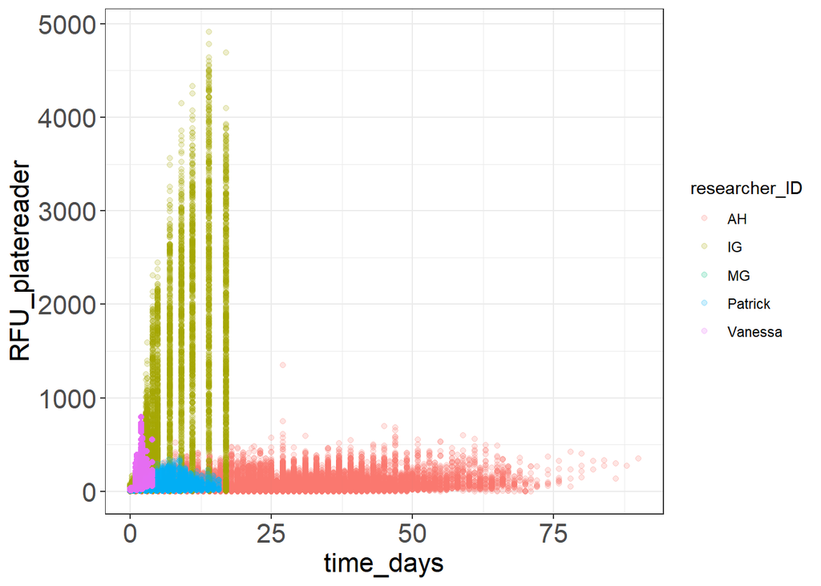

```r
df %>%
  ggplot(aes(time_days, RFU_platereader, color = researcher_ID))+
  geom_point(alpha=.2)
```

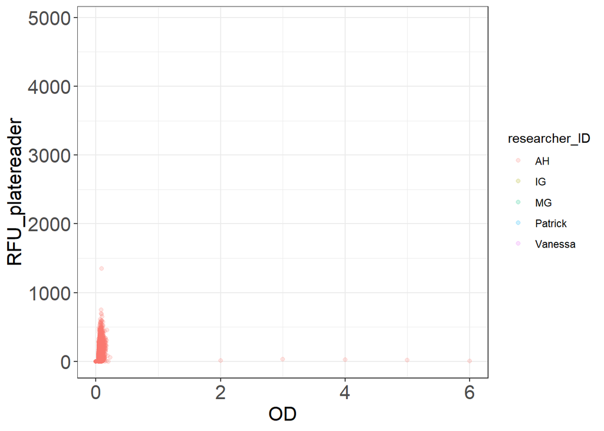

```r
df %>%
  ggplot(aes(OD, RFU_platereader, color = researcher_ID))+
  geom_point(alpha=.2)
```

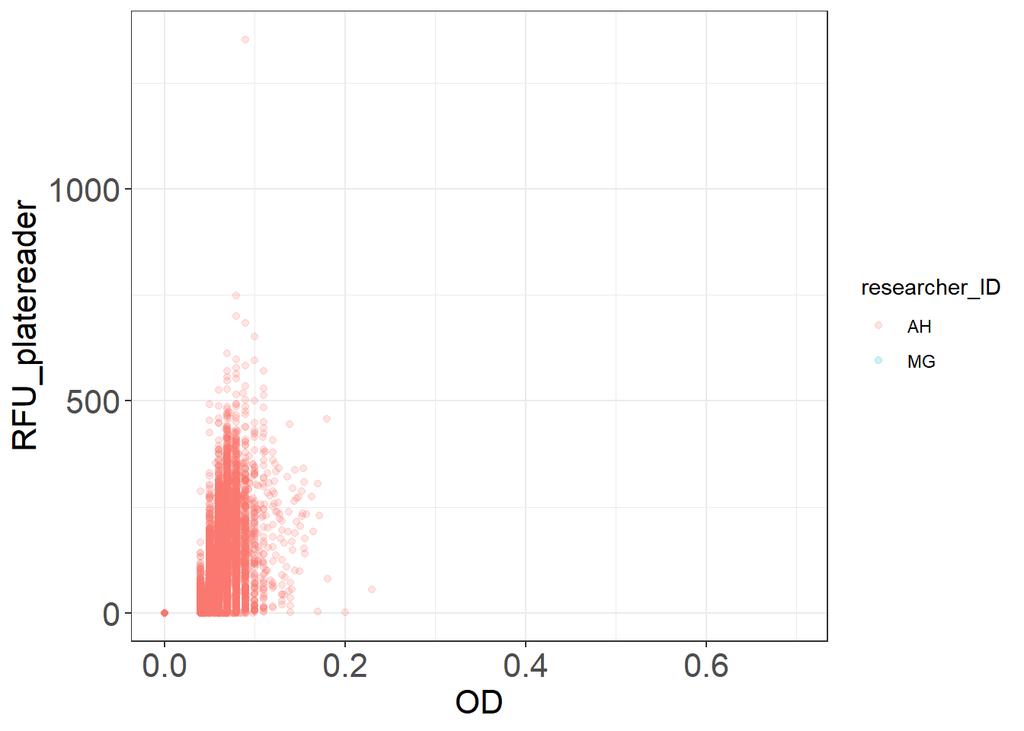

```r
df %>% filter(OD<1.5) %>%
  ggplot(aes(OD, RFU_platereader, color = researcher_ID))+
  geom_point(alpha=.2)
```

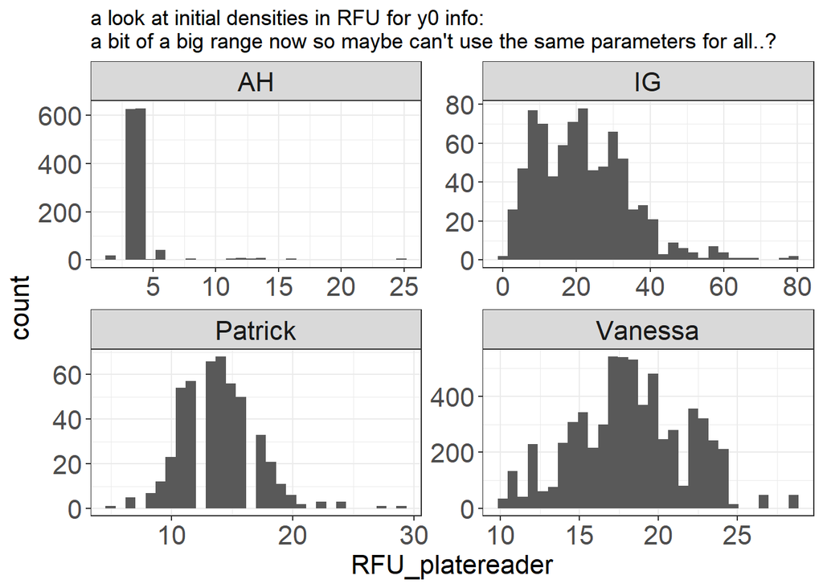

```r
df %>% filter(time_days <0.05) %>%
  ggplot(aes(RFU_platereader))+
  geom_histogram()+
  facet_wrap(~researcher_ID, scales = 'free')+
  ggtitle("a look at initial densities in RFU for y0 info: \na bit of a big range now so maybe can't use the same parameters for all..?")
```

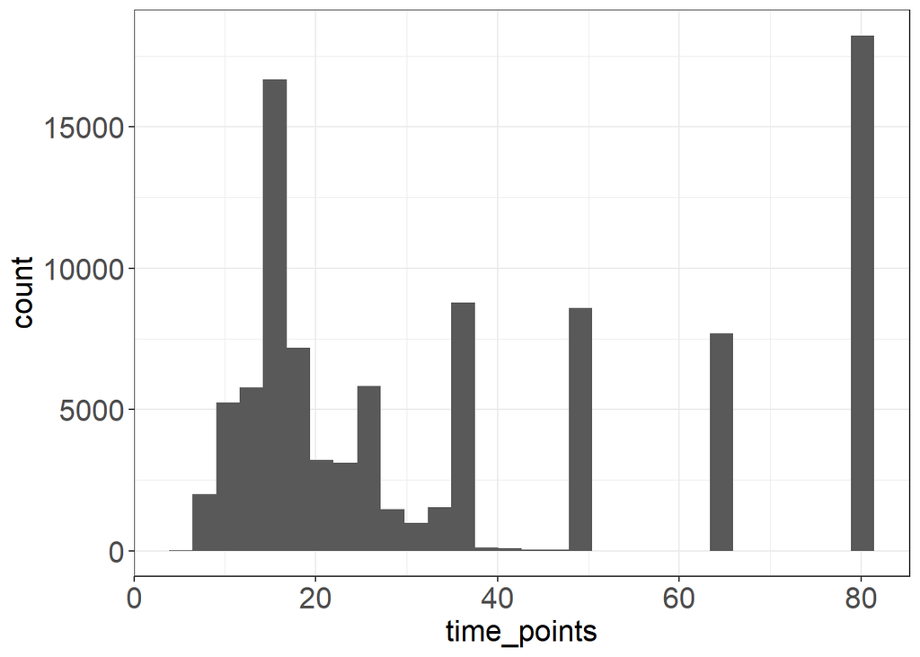

```r
df %>%
  ggplot(aes(time_points))+
  geom_histogram()
```

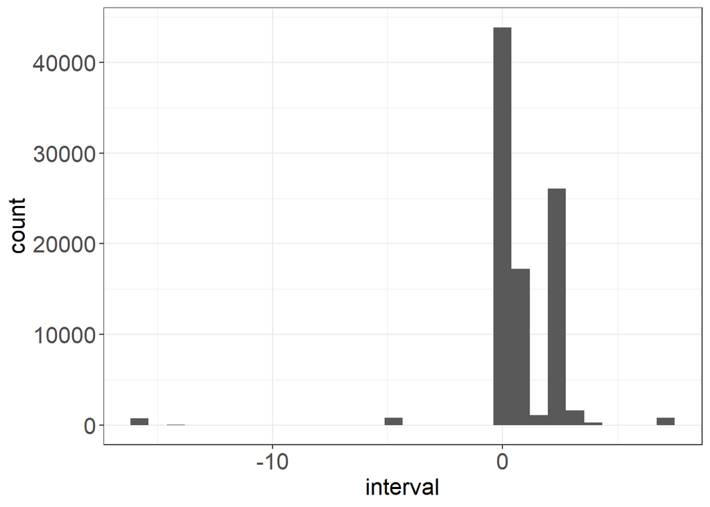

```r
df %>%
  ggplot(aes(interval))+
  geom_histogram()
```

# 2 Test runs with reduced datasets

> making a small test dataset for trying different approaches [maybe next step is to take 20 growth curves from each of our experiments and compare that as a test]

```r
IDs <- unique(df$unique_ID)
test <- df %>% filter(unique_ID %in% IDs[1:20]) #trying to subset just the first 20 experimental units/growth curves
length(unique(test$unique_ID)) #ok that worked
```

```
## [1] 20
```

> already got this message trying to run even a subset of the data the first time….but worked eventually

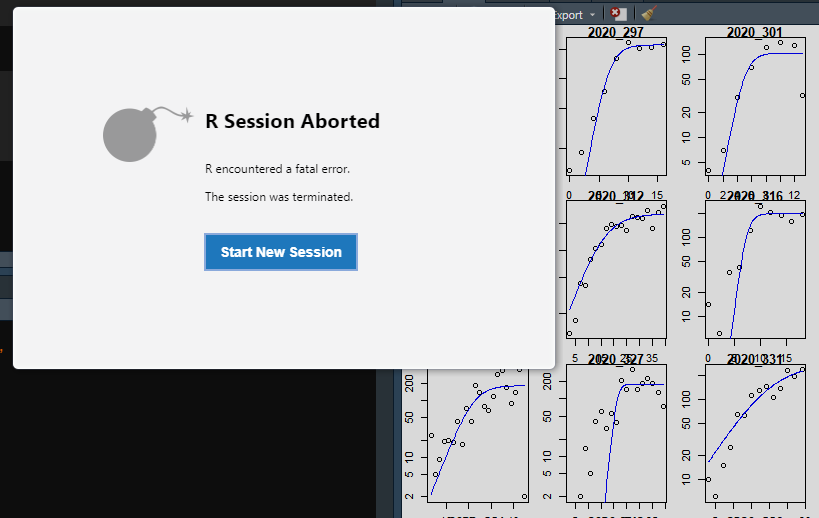

```r
p     <- c(y0 = 5, mumax = 0.5, K = 50)
lower <- c(y0 = 0, mumax = -5,   K = 0)
upper <- c(y0 = 30, mumax = 2,   K = 800)

start_time <- Sys.time()
test_logistic_fits <- all_growthmodels(
                   RFU_platereader ~ grow_logistic(time_days, parms) | unique_ID,
                   data = test,
                   p = p, lower = lower, upper = upper,
                   log = "y", ncores=2)
end_time <- Sys.time()
logistic_test_time <- end_time - start_time
logistic_test_time
```

```
## Time difference of 6.015909 secs
```

```r
test_logistic_results <- results(test_logistic_fits) %>%
  mutate(model = "growthrates::logistic")%>%
  select(unique_ID, mumax, model, r2)
```

> that approach took 6.02 seconds to calculate 20 growth rates

> plotting above curves

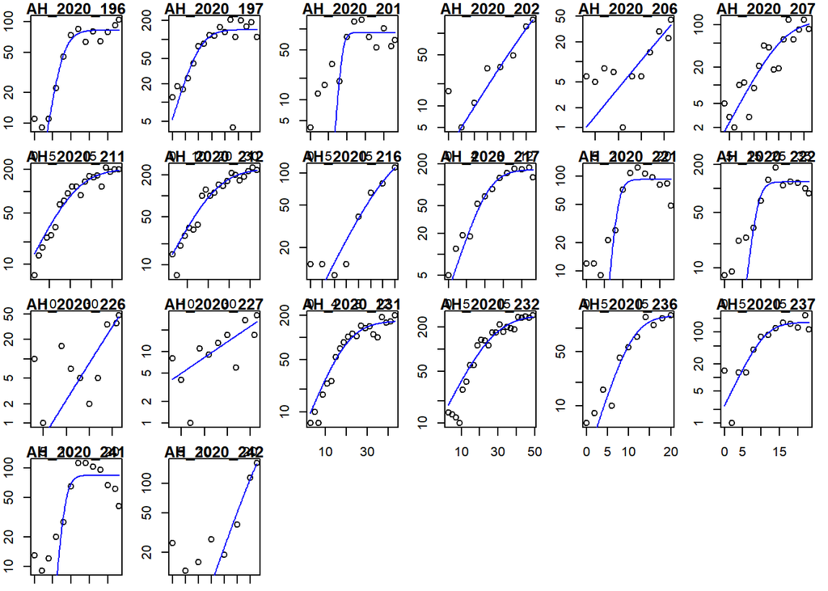

```r
par(mfrow = c(4, 6))
par(mar=c(1,2,1,1))
plot(test_logistic_fits, log = "y")
```

# 3 Growth rate calculations for full dataset

> quickly trying the 2-point growth rate approach by taking the max increase over between two adjacent time points (i.e., either 1, 2, or 4 days depending on the sampling interval)

```r
start_time <- Sys.time()

max_diffs <- df %>%
  mutate(logRFU = log(RFU_platereader)) %>%
  group_by(unique_ID, researcher_ID, system) %>%
  mutate(deltalogRFU = logRFU - dplyr::lag(logRFU, n=1)) %>%
  mutate(deltatime = time_days - dplyr::lag(time_days, n=1)) %>%
  mutate(mu = deltalogRFU/deltatime)

max_rates <- max_diffs %>%
  group_by(unique_ID, researcher_ID, system) %>%
  summarize(mumax = max(mu, na.rm = TRUE)) %>%
  mutate(model="max_diff_2days") %>%
  mutate(r2 = "NA") %>%
  mutate(r2=as.numeric(r2))

end_time <- Sys.time()
maxdiff_time <- end_time - start_time
```

> that approach took 13.83 seconds to calculate 3339 growth rates

> also there are a lot of NA and Inf values so need to check why that is….

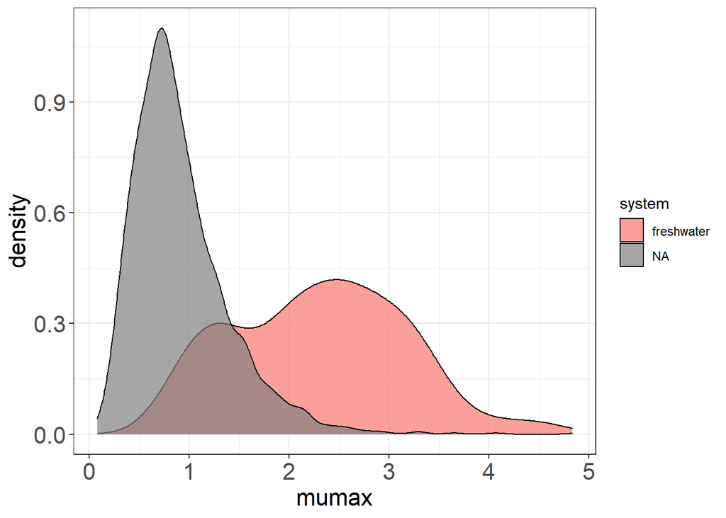

```r
max_rates %>% ggplot(aes(mumax, fill = system))+
  geom_density(alpha = 0.7)
```

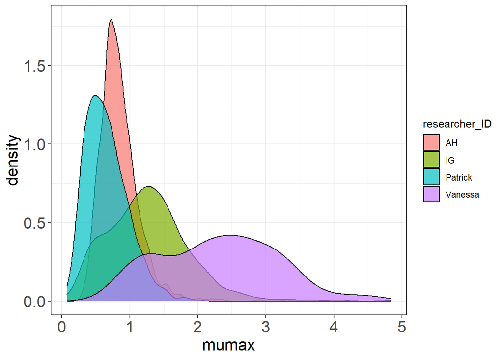

```r
max_rates %>% ggplot(aes(mumax, fill = researcher_ID))+
  geom_density(alpha = 0.7)
```

> notes so far:
- combining data works pretty well overall!
- differences in formatting stuff like commas vs periods and different column names are minor problems but can be fixed
- running the full dataset might in the `growthrates` package might kill my computer

```r
knitr::knit_exit()
```